# Tarea 2 CDE

Bastián Juan, José Pedro Guzmán, Guillermo Ugarte

2022-06-05

# Introducción

### Para este estudio nosotros elegimos a la Laguna La Mula ya que es una resesrva ecológica (Reserva Nacional de Ralco) ubicada en Alto Biobío que es conocida por ser de bastante difícil acceso para los vehículos comunes. Elegimos como punto de partida a Santa Bárbara (en específico su municipalidad) ya que es de las localidades con más población más cercanas a la laguna. Para esto se analizarán las rutas de acceso a pie y la ruta por vehículo terrestre. Nuesta data fue obtenida desde la página oficial del gobierno de Chile y, por otra parte, complementando con los datos que se han visto en clases disponibles en los respositorios y en Webcursos.

### Para iniciar nuestro estudio, dentro de la variable “Urban” se debe de elegir el archivo “Zonas_urbanas_2017_Chile.shp” para cargar los datos terrestres.

```r
# Primero, definimos nuestro sf, el cual corresponde a las zonas urbanas de Chile

Urban <- sf::st_read(file.choose())
```

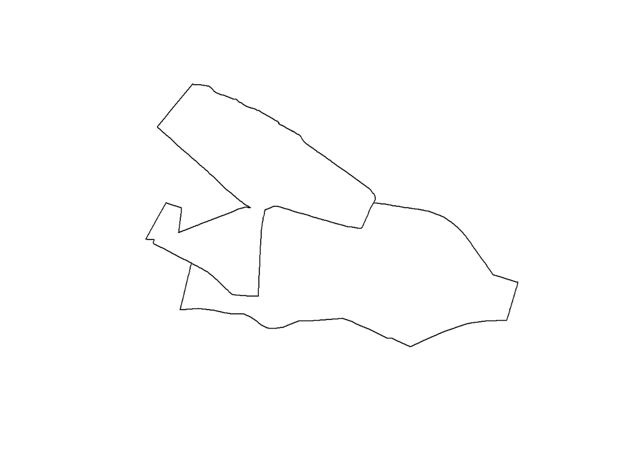

```r
# Filtramos los datos de las comunas que no ocuparemos
filterurban <- dplyr::select(Urban, -COMUNA, -Shape_Leng, -Shape_Area, -GEOCODIGO, -PROVINCIA)

# Utilizaremos la distancia desde la municipalidad de Santa B?rbara hasta la laguna La Mula

SantaBarbara <- filterurban[filterurban$URBANO == "SANTA BÁRBARA",]
SantaBarbara <- na.omit(SantaBarbara)

plot(SantaBarbara$geometry)
```

Una vez visualizada la región de Santa Bárbara se deberá cargar la información con los cuerpos de agua de Chile, el cual será el archivo llamado “CuerposdeAgua.shp”, para poder seguir con nuestro estudio.

```r
# Ahora, cargamos la informaci?n de los cuerpos de agua de Chile

LagosChile <- sf::st_read(file.choose())
```

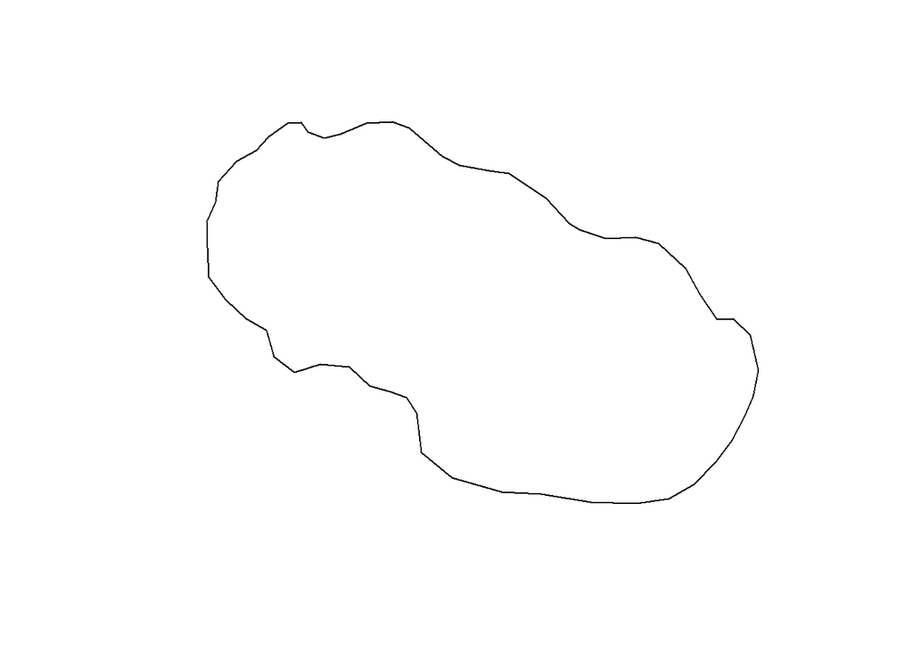

```r
# Sacamos solamente las columnas que nos interesan

LagosChileFilter <- dplyr::select(LagosChile, nombre, tipo, geometry)

LagunaLaMula <- LagosChileFilter[LagosChileFilter$nombre=="Laguna La Mula",]
LagunaLaMula <- na.omit(LagunaLaMula)

plot(LagunaLaMula$geometry)
```

Ya desplegadas las vistas de los mapas de la Laguna La Mula, ahora viene una de las partes cruciales para el proyecto: conectar la Municipalidad de Santa Bárbara con la laguna de nuestro estudio. Para esto se necesitará la nueva librería “Osrm”.

Para iniciar esta parte lo que se hizo fue conectar ambas zonas. Primero se hizo con lo que sería una ruta para llegar a la laguna en auto o cualquier otro vehículo motorizado. Luego se conectó pero con una ruta que sería hecha a pie.

```r
# Para el c?lculo de la accesibilidad, ocuparemos la librer?a OSRM
#install.packages('osrm')
library(osrm)
options(osrm.server = 'https://routing.openstreetmap.de/')
coord <- data.frame(lugar = c('Municipalidad de Santa B?rbara', 'Laguna La mUla'), lon = c(-72.0214, -71.3667), lat = c(-37.6706, -37.8833))
coord <- sf::st_as_sf(x = coord, coords = c('lon', 'lat'), crs = sf::st_crs(4326))

rutacar <- osrm::osrmRoute(src = coord[1,], dst = coord[2,], returnclass = 'sf', osrm.profile ='car')
rutapie <- osrm::osrmRoute(src = coord[1,], dst = coord[2,], returnclass = 'sf', osrm.profile = 'foot')


rutacar
```

```
## Simple feature collection with 1 feature and 4 fields
## Geometry type: LINESTRING
## Dimension:     XY
## Bounding box:  xmin: -72.02109 ymin: -38.08854 xmax: -71.31174 ymax: -37.67064
## Geodetic CRS:  WGS 84
##     src dst duration distance                       geometry
## 1_2   1   2  178.015 128.2683 LINESTRING (-72.02109 -37.6...
```

Dentro de todos estos valores desplegados nos fijamos en los 2 más importantes. El primero llamado “duration” es la duración en minutos que nos tardaríamos en hacer la ruta que se desplegará más abajo, que en este caso sería la ruta roja. El otro valor a observar es el llamado “distance” que es la distancia de la ruta del mismo color en kilómetros.

```r
rutapie
```

```
## Simple feature collection with 1 feature and 4 fields
## Geometry type: LINESTRING
## Dimension:     XY
## Bounding box:  xmin: -72.02109 ymin: -37.904 xmax: -71.36538 ymax: -37.67064
## Geodetic CRS:  WGS 84
##     src dst duration distance                       geometry
## 1_2   1   2 1156.242   86.713 LINESTRING (-72.02109 -37.6...
```

Ahora se nos desplegará una ventana similar a la anterior, pero que en este caso se refiere a la ruta azul, la que nos indica cómo sería, cuánto se demoraría y cuánto mide la ruta a realizar, pero en este caso al hacerla a pie.

```r
library(mapview)
mapview::mapview(rutacar) + mapview(rutapie, color = 'red')
```

[interactive chart not shown]

```r
library(mapview)
mapview::mapview(SantaBarbara$geometry, col.regions = 'green') + mapview(LagunaLaMula$geometry) + mapview::mapview(rutacar, color = 'red') + mapview::mapview(rutapie)
```

[interactive chart not shown]

Como se puede apreciar en los mapas interactivos cargados, en el primero se ven solo las rutas hechas con vehículo y las rutas hechas a pie, separadas con colores distintos para poder distinguirlas, a diferencia que con el segundo mapa se pueden ver restaltadas con colores y como objetos dentro del mapa los puntos de partida y de llegada, en este caso: Santa Bárbara y la Laguna La Mula.

```r
# Ahora, veremos el google earth engine

pacman::p_load(raster, mapview, sf, rgdal)
#install.packages('rgee')

# Cargamos las librer?as de Google Drive y Google Earth Engine
library(googledrive)
library(rgee)
#ee_reattach() # reattach ee as a reserve word
# Initialize just Earth Engine
#ee_Initialize()
#ee_Initialize(user = 'b.juanalvarez@gmail.com') # Use the argument email is not mandatory, but it's helpful to change of EE user.
# Initialize Earth Engine and GD
#ee_Initialize(user = 'b.juanalvarez@gmail.com', drive = TRUE)
# Initialize Earth Engine and GCS
#ee_Initialize(user = 'b.juanalvarez@gmail.com', gcs = TRUE)
# Initialize Earth Engine, GD and GCS
#ee_Initialize(user = 'b.juanalvarez@gmail.com', drive = TRUE, gcs = TRUE)


ee_Initialize('bastianjuan', drive = TRUE)
```

```
## ── rgee 1.1.3 ─────────────────────────────────────── earthengine-api 0.1.312 ──
##  ✔ user: bastianjuan
##  ✔ Google Drive credentials:
 ✔ Google Drive credentials:  FOUND
##  ✔ Initializing Google Earth Engine:
 ✔ Initializing Google Earth Engine:  DONE!
##
 ✔ Earth Engine account: users/bastianjuan
## ────────────────────────────────────────────────────────────────────────────────
```

En este punto es cuando comenzamos a utilizar el tan ansiado Google Earth Engine para poder acceder a las imágenes satelitales y a sus distintos filtros disponibles, como la sección RGB para poder ver solamente la luz visible, filtros ultravioleta, infrarrojos, detectodes de clorofila y más.

```r
# Seleccionamos el satélite LANDSAT 8, filtrando la data para el a?o 2020 de la Laguna La mula
coll <-ee$ImageCollection('LANDSAT/LC08/C01/T1_TOA')$
  filterDate('2019-04-01', '2020-06-30')$
  filterBounds(ee$Geometry$Point(-71.369629,-37.894510))$
  filterMetadata('CLOUD_COVER', 'less_than',10)

# Obtenemos la fecha exacta de la imagen captada por el sat?lite
ee_get_date_ic(coll)
```

```
##                                              id          time_start
## 1  LANDSAT/LC08/C01/T1_TOA/LC08_232086_20190406 2019-04-06 14:28:12
## 2  LANDSAT/LC08/C01/T1_TOA/LC08_232086_20190422 2019-04-22 14:28:06
## 3  LANDSAT/LC08/C01/T1_TOA/LC08_232086_20190609 2019-06-09 14:28:29
## 4  LANDSAT/LC08/C01/T1_TOA/LC08_232086_20190812 2019-08-12 14:28:48
## 5  LANDSAT/LC08/C01/T1_TOA/LC08_232086_20190913 2019-09-13 14:28:57
## 6  LANDSAT/LC08/C01/T1_TOA/LC08_232086_20200103 2020-01-03 14:28:54
## 7  LANDSAT/LC08/C01/T1_TOA/LC08_232086_20200119 2020-01-19 14:28:50
## 8  LANDSAT/LC08/C01/T1_TOA/LC08_232086_20200220 2020-02-20 14:28:42
## 9  LANDSAT/LC08/C01/T1_TOA/LC08_232086_20200323 2020-03-23 14:28:28
## 10 LANDSAT/LC08/C01/T1_TOA/LC08_232086_20200408 2020-04-08 14:28:20
## 11 LANDSAT/LC08/C01/T1_TOA/LC08_232086_20200526 2020-05-26 14:28:08
## 12 LANDSAT/LC08/C01/T1_TOA/LC08_232087_20190422 2019-04-22 14:28:29
## 13 LANDSAT/LC08/C01/T1_TOA/LC08_232087_20200103 2020-01-03 14:29:18
## 14 LANDSAT/LC08/C01/T1_TOA/LC08_232087_20200119 2020-01-19 14:29:14
## 15 LANDSAT/LC08/C01/T1_TOA/LC08_232087_20200220 2020-02-20 14:29:06
## 16 LANDSAT/LC08/C01/T1_TOA/LC08_232087_20200408 2020-04-08 14:28:44
## 17 LANDSAT/LC08/C01/T1_TOA/LC08_233086_20190429 2019-04-29 14:34:17
## 18 LANDSAT/LC08/C01/T1_TOA/LC08_233086_20190718 2019-07-18 14:34:49
## 19 LANDSAT/LC08/C01/T1_TOA/LC08_233086_20190803 2019-08-03 14:34:56
## 20 LANDSAT/LC08/C01/T1_TOA/LC08_233086_20190920 2019-09-20 14:35:10
## 21 LANDSAT/LC08/C01/T1_TOA/LC08_233086_20191022 2019-10-22 14:35:16
## 22 LANDSAT/LC08/C01/T1_TOA/LC08_233086_20191209 2019-12-09 14:35:10
## 23 LANDSAT/LC08/C01/T1_TOA/LC08_233086_20191225 2019-12-25 14:35:07
## 24 LANDSAT/LC08/C01/T1_TOA/LC08_233086_20200110 2020-01-10 14:35:03
## 25 LANDSAT/LC08/C01/T1_TOA/LC08_233086_20200211 2020-02-11 14:34:55
## 26 LANDSAT/LC08/C01/T1_TOA/LC08_233086_20200227 2020-02-27 14:34:50
## 27 LANDSAT/LC08/C01/T1_TOA/LC08_233086_20200314 2020-03-14 14:34:44
## 28 LANDSAT/LC08/C01/T1_TOA/LC08_233086_20200330 2020-03-30 14:34:35
## 29 LANDSAT/LC08/C01/T1_TOA/LC08_233086_20200501 2020-05-01 14:34:20
```

```r
L8 <- 'LANDSAT/LC08/C01/T1_TOA/LC08_233086_20200330' %>%
  ee$Image() %>%
  ee$Image$select(c('B6', 'B5', 'B4', 'B3'))

# Ploteamos el mapa de GGE
Map$centerObject(L8)
Map$addLayer(L8)
```

[interactive chart not shown]

Para el primer mapa se utilizaron 4 bandas: B3 y B4 correspondientes a la capa verde y rojas respectivamente, y B5 junto con B6 correspondientes a la capa infrarroja y a la Short Wave Infrared 1. Logrando la imagen adjunta.

```r
library(geojson)
roi <-
  c(-71.369629, -37.894510) %>%  # Acceso a la Laguna La Mula.
  sf::st_point(dim = "XYZ") %>%
  sf::st_buffer(dist = 0.2) %>%
  sf_as_ee()

Map$centerObject(roi, zoom = 15)
Map$addLayer(roi)
```

[interactive chart not shown]

Previo a utlizar las bandas de nuestra mayor preferencia decidimos realizar un corte para poder definir bien nuestra región de interés, en este caso llamada “roi” y se desplega para verificar su correcta visualización.

```r
getNDWI <- function(image) {
  image$normalizedDifference(c("B3", "B5"))
}

# Ahora visualizamos las capas por separado para poder analizar el cuerpo de agua
ndwi <- getNDWI(L8)
library(cptcity)
Map$centerObject(roi, zoom = 15)
Map$addLayer(ndwi, visParams = list(palette = cpt("ds9_rainbow", 10)))
```

[interactive chart not shown]

#Resultados y conclusión

### Como se puede notar por todos los datos obtenidos anteriormente, las distancias, ya sean recorridas a pie o en vehículo (que tampoco puede ser cualquier vehículo) son bastante largas e implican un tiempo de viaje muy largo en ambas situaciones. Para realizar la dura desde la municipalidad de Santa Bárbara hasta la laguna en auto 178 minutos, lo que se traduce a poco menos de 3 horas (2 horas y 58 minutos para ser exactos), todo esto recorriendo una distancia de 128 kilómetros. Cabe destacar que toda esta demora en auto se debe en gran parte a que el camino no está pavimentando, estando compuesto en su mayoría por un camino de tierra que al final adapta una forma sinusoidal. Para el camino a pie notamos que sería un trayecto aproximadamente 40 kilómetros más corto, pero como al hacerse a pie, sería mucho más demoroso llegando a 1156 minutos, lo que equivale a 19 horas y 16 minutos aproximadamente.

### Una vez vistos y analizados los resultados, podemos concluir que la Laguna La Mula es un lugar de muy difícil acceso tanto para los vehículos terrestres como para hacer la ruta a pie. Como se puede ver en la imagen final, tiene un ecosistema bien definido y rico en zonas húmedas en formas ya sea de agua y/o nieve a su alrededor, siendo muy próximo al volcán Callaqui (el cual se puede identificar gracias a su tamaño y a su ecosistema rico en cuerpos de agua). Sumando a lo anterior, teniendo el cuenta el difícil acceso que se tiene a esta zona, puede ser una de las razones del porqué se ha conservado durante los años y no se ha secado como muchas lagunas similares, dado que es una zona no interferida usualmente por la población ni por los turistas, esto ayuda a mantener su ecosistema de manera intacta según los datos utilizados (hasta junio del 2020).